# EDA_Questions_3

# 3 -- API_CALL_STS_TXT Status of API call.

```
Summary Statistics:
count          15
unique          2
top       Success
freq           13
Name: API_CALL_STS_TXT, dtype: object

Unique Values and Counts:
Success    13
Failed      2
Name: API_CALL_STS_TXT, dtype: int64
```

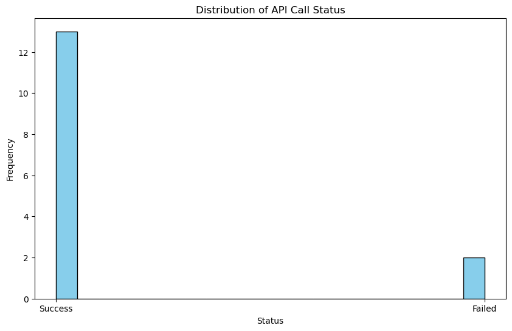

```python
import pandas as pd



api_call_status = df['API_CALL_STS_TXT']

# Get summary statistics
summary_stats = api_call_status.describe()
print("Summary Statistics:")
print(summary_stats)

# Get unique values and their counts
unique_values_counts = api_call_status.value_counts()
print("\nUnique Values and Counts:")
print(unique_values_counts)

# Plot a histogram to visualize the distribution of values
import matplotlib.pyplot as plt
plt.figure(figsize=(10, 6))
api_call_status.hist(bins=20, color='skyblue', edgecolor='black')
plt.title('Distribution of API Call Status')
plt.xlabel('Status')
plt.ylabel('Frequency')
plt.grid(False)
plt.show()
```

# 4 --ATMP_CNT Count of Attempts.

```
Summary Statistics for Attempt Count:
count    15.000000
mean      2.000000
std       0.377964
min       1.000000
25%       2.000000
50%       2.000000
75%       2.000000
max       3.000000
Name: ATMP_CNT, dtype: float64

Unique Values and Counts for Attempt Count:
2    13
1     1
3     1
Name: ATMP_CNT, dtype: int64
```

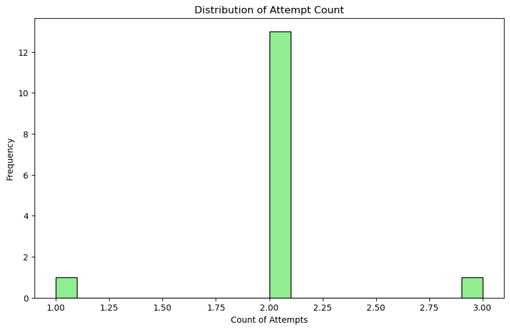

```python
import pandas as pd

# Load the dataset into a Pandas DataFrame
# Assuming the dataset is already loaded and stored in a variable called 'df'
# If not, you can load it using pd.read_csv() or pd.read_excel(), depending on the file format

# Assuming 'ATMP_CNT' is the column of interest
attempt_count = df['ATMP_CNT']

# Get summary statistics
summary_stats = attempt_count.describe()
print("Summary Statistics for Attempt Count:")
print(summary_stats)

# Get unique values and their counts
unique_values_counts = attempt_count.value_counts()
print("\nUnique Values and Counts for Attempt Count:")
print(unique_values_counts)

# Plot a histogram to visualize the distribution of values
import matplotlib.pyplot as plt
plt.figure(figsize=(10, 6))
attempt_count.hist(bins=20, color='lightgreen', edgecolor='black')
plt.title('Distribution of Attempt Count')
plt.xlabel('Count of Attempts')
plt.ylabel('Frequency')
plt.grid(False)
plt.show()
```

# 5 ---CALL_RSLT_TXT Response code returned from API.

```
Summary Statistics for Response Code:
count    10.00000
mean     87.70000
std      24.08342
min      35.00000
25%      99.00000
50%      99.00000
75%      99.00000
max      99.00000
Name: CALL_RSLT_TXT, dtype: float64

Unique Values and Counts for Response Code:
99.0    8
35.0    1
50.0    1
Name: CALL_RSLT_TXT, dtype: int64
```

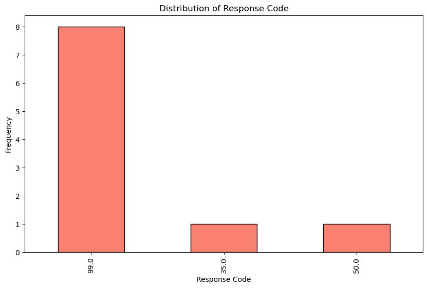

```python
response_code = df['CALL_RSLT_TXT']

# Get summary statistics
summary_stats = response_code.describe()
print("Summary Statistics for Response Code:")
print(summary_stats)

# Get unique values and their counts
unique_values_counts = response_code.value_counts()
print("\nUnique Values and Counts for Response Code:")
print(unique_values_counts)

# Plot a bar chart to visualize the distribution of values
import matplotlib.pyplot as plt
plt.figure(figsize=(10, 6))
unique_values_counts.plot(kind='bar', color='salmon', edgecolor='black')
plt.title('Distribution of Response Code')
plt.xlabel('Response Code')
plt.ylabel('Frequency')
plt.grid(False)
plt.show()
```

# 5 --- CASH_RGSTR_ID A unique identifier for this cash register generated by the data warehouse ETL.

##### This cash register identifier is a proxy substitute for the Cash Register Number within this Sales Outlet.

```
Summary Statistics for Cash Register ID:
count    1.500000e+01
mean     6.435265e+08
std      1.537222e+08
min      8.790655e+07
25%      6.824376e+08
50%      6.840866e+08
75%      6.843883e+08
max      6.849197e+08
Name: CASH_RGSTR_ID, dtype: float64

Unique Values and Counts for Cash Register ID:
682244601    1
684426136    1
87906551     1
676791879    1
684655662    1
682630664    1
684903145    1
684343750    1
682726618    1
684919749    1
684021132    1
684098673    1
680792111    1
684086617    1
684350430    1
Name: CASH_RGSTR_ID, dtype: int64
```

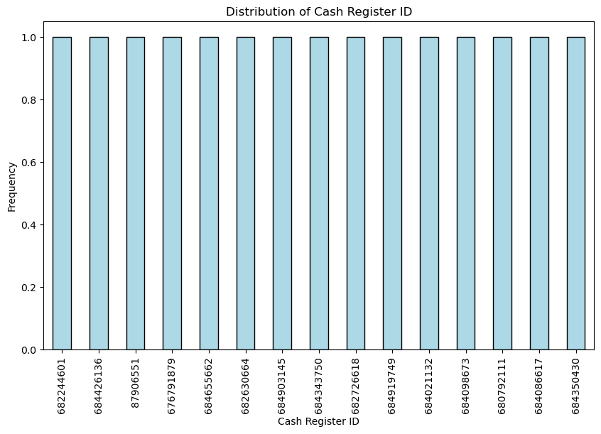

```python
cash_register_id = df['CASH_RGSTR_ID']

# Get summary statistics
summary_stats = cash_register_id.describe()
print("Summary Statistics for Cash Register ID:")
print(summary_stats)

# Get unique values and their counts
unique_values_counts = cash_register_id.value_counts()
print("\nUnique Values and Counts for Cash Register ID:")
print(unique_values_counts)

# Plot a bar chart to visualize the distribution of values
import matplotlib.pyplot as plt
plt.figure(figsize=(10, 6))
unique_values_counts.plot(kind='bar', color='lightblue', edgecolor='black')
plt.title('Distribution of Cash Register ID')
plt.xlabel('Cash Register ID')
plt.ylabel('Frequency')
plt.grid(False)
plt.show()
```

# 6--- CRDT_APP_NBR "This column will have credit application number

```
Summary Statistics for Credit Application Number:
count    7.000000e+00
mean     4.040170e+11
std      0.000000e+00
min      4.040170e+11
25%      4.040170e+11
50%      4.040170e+11
75%      4.040170e+11
max      4.040170e+11
Name: CRDT_APP_NBR, dtype: float64

Unique Values and Counts for Credit Application Number:
4.040170e+11    7
Name: CRDT_APP_NBR, dtype: int64
```

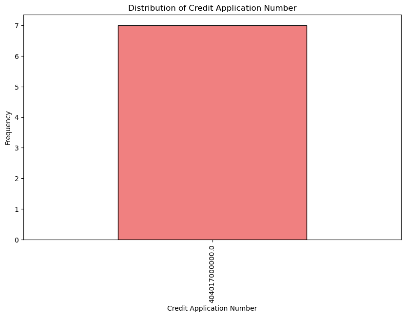

```python
# Assuming 'CRDT_APP_NBR' is the column of interest
credit_application_number = df['CRDT_APP_NBR']

# Get summary statistics
summary_stats = credit_application_number.describe()
print("Summary Statistics for Credit Application Number:")
print(summary_stats)

# Get unique values and their counts
unique_values_counts = credit_application_number.value_counts()
print("\nUnique Values and Counts for Credit Application Number:")
print(unique_values_counts)

# Plot a bar chart to visualize the distribution of values
import matplotlib.pyplot as plt
plt.figure(figsize=(10, 6))
unique_values_counts.plot(kind='bar', color='lightcoral', edgecolor='black')
plt.title('Distribution of Credit Application Number')
plt.xlabel('Credit Application Number')
plt.ylabel('Frequency')
plt.grid(False)
plt.show()
```

# 7 -- CUST_NM Customer Name from ID as returned from Authentic ID API.

```
First few rows of Customer Name:
0         JONI HELEN WILSON
1                       NaN
2                       NaN
3    CORAZON DE JESUS HOGLE
4                       NaN
Name: CUST_NM, dtype: object

Unique Values and Counts for Customer Name:
JONI HELEN WILSON                         1
CORAZON DE JESUS HOGLE                    1
GERARDO CABRAL                            1
JESUS MAN GUTIERREZ TORREALBA             1
DEBORAH DAVIS HARWELL                     1
YOALIZZETTE BEATRIZ URDANETA FERNANDEZ    1
AILIE ELENA SANDS                         1
TINA MARIE SYKES                          1
MICHELE ANN ADAMS                         1
Name: CUST_NM, dtype: int64
```

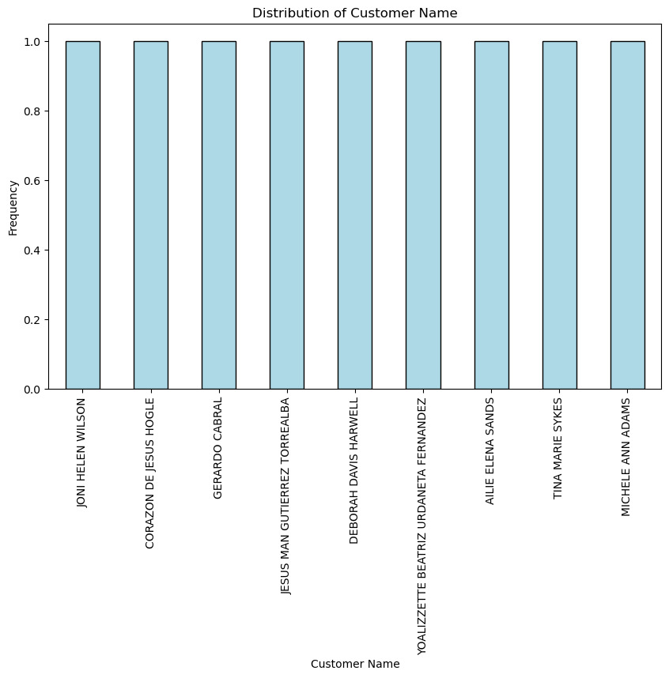

```python
import pandas as pd
import matplotlib.pyplot as plt

# Load the dataset into a Pandas DataFrame
# Assuming the dataset is already loaded and stored in a variable called 'df'
# If not, you can load it using pd.read_csv() or pd.read_excel(), depending on the file format

# Assuming 'CUST_NM' is the column of interest
customer_name = df['CUST_NM']

# Display the first few rows of the column
print("First few rows of Customer Name:")
print(customer_name.head())

# Get unique values and their counts
unique_values_counts = customer_name.value_counts()
print("\nUnique Values and Counts for Customer Name:")
print(unique_values_counts)

# Plot a bar chart to visualize the distribution of values
plt.figure(figsize=(10, 6))
unique_values_counts.plot(kind='bar', color='lightblue', edgecolor='black')
plt.title('Distribution of Customer Name')
plt.xlabel('Customer Name')
plt.ylabel('Frequency')
plt.grid(False)
plt.show()
```

# 8 -- CUST_RESP_TXT Bypass option chosen by customer.

```
First few rows of Customer Response Text:
0     Accept
1    Decline
2     Accept
3     Accept
4     Accept
Name: CUST_RESP_TXT, dtype: object

Unique Values and Counts for Customer Response Text:
Accept     14
Decline     1
Name: CUST_RESP_TXT, dtype: int64
```

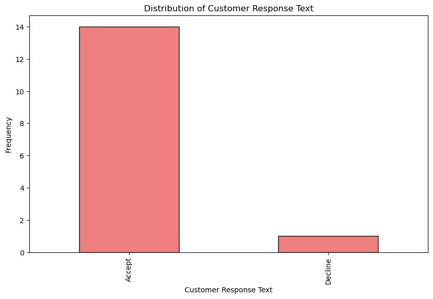

```python
import pandas as pd
import matplotlib.pyplot as plt

# Load the dataset into a Pandas DataFrame
# Assuming the dataset is already loaded and stored in a variable called 'df'
# If not, you can load it using pd.read_csv() or pd.read_excel(), depending on the file format

# Assuming 'CUST_RESP_TXT' is the column of interest
customer_response_text = df['CUST_RESP_TXT']

# Display the first few rows of the column
print("First few rows of Customer Response Text:")
print(customer_response_text.head())

# Get unique values and their counts
unique_values_counts = customer_response_text.value_counts()
print("\nUnique Values and Counts for Customer Response Text:")
print(unique_values_counts)

# Plot a bar chart to visualize the distribution of values
plt.figure(figsize=(10, 6))
unique_values_counts.plot(kind='bar', color='lightcoral', edgecolor='black')
plt.title('Distribution of Customer Response Text')
plt.xlabel('Customer Response Text')
plt.ylabel('Frequency')
plt.grid(False)
plt.show()
```

# 9 -- DLR_1_DESC Dealer Code 1.

```python
# Assuming 'DLR_1_DESC' is the column of interest
dealer_code_1 = df['DLR_1_DESC']

# Display the first few rows of the column
print("First few rows of Dealer Code 1:")
print(dealer_code_1.head())

# Get summary statistics
unique_values_counts = dealer_code_1.value_counts()
print("\nUnique Values and Counts for Dealer Code 1:")
print(unique_values_counts)
```

```
First few rows of Dealer Code 1:
0    7LYLN
1    9NEOO
2    22EKS
3      994
4    222GK
Name: DLR_1_DESC, dtype: object

Unique Values and Counts for Dealer Code 1:
22EKS    2
7LYLN    1
9NEOO    1
994      1
222GK    1
8OX20    1
22FN2    1
KHP8A    1
JH8GG    1
AVT9J    1
RVK45    1
GGHU4    1
KNNVF    1
45VGM    1
Name: DLR_1_DESC, dtype: int64
```

# 10 -- DLR_1_DESC Dealer Code 1.

```
First few rows of Dealer Code 1:
0    7LYLN
1    9NEOO
2    22EKS
3      994
4    222GK
Name: DLR_1_DESC, dtype: object

Summary Statistics for Dealer Code 1:
count        15
unique       14
top       22EKS
freq          2
Name: DLR_1_DESC, dtype: object

Unique Values and Counts for Dealer Code 1:
22EKS    2
7LYLN    1
9NEOO    1
994      1
222GK    1
8OX20    1
22FN2    1
KHP8A    1
JH8GG    1
AVT9J    1
RVK45    1
GGHU4    1
KNNVF    1
45VGM    1
Name: DLR_1_DESC, dtype: int64
```

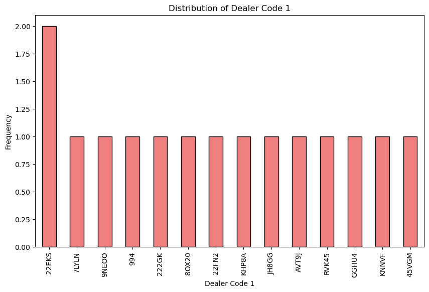

```python
import pandas as pd
import matplotlib.pyplot as plt

# Load the dataset into a Pandas DataFrame
# Assuming the dataset is already loaded and stored in a variable called 'df'
# If not, you can load it using pd.read_csv() or pd.read_excel(), depending on the file format

# Assuming 'DLR_1_DESC' is the column of interest
dealer_code_1 = df['DLR_1_DESC']

# Display the first few rows of the column
print("First few rows of Dealer Code 1:")
print(dealer_code_1.head())

# Get summary statistics
summary_stats = dealer_code_1.describe()
print("\nSummary Statistics for Dealer Code 1:")
print(summary_stats)

# Get unique values and their counts
unique_values_counts = dealer_code_1.value_counts()
print("\nUnique Values and Counts for Dealer Code 1:")
print(unique_values_counts)

# Plot a bar chart to visualize the distribution of values
plt.figure(figsize=(10, 6))
unique_values_counts.plot(kind='bar', color='lightcoral', edgecolor='black')
plt.title('Distribution of Dealer Code 1')
plt.xlabel('Dealer Code 1')
plt.ylabel('Frequency')
plt.grid(False)
plt.show()
```

# 11 -- DOC_ID_TXT ID assigned to the document by Vendor API

```
First few rows of Document ID:
0    c804cce2-bb45-4d74-ad92-260d6fc714fe
1                                     NaN
2    2e811dde-c0ac-47d9-ab4b-6f46aafab8b2
3    302a6a5f-e86e-405a-9c02-2143bf847bcd
4    3e1a4c1d-e906-419b-9e36-3526711652f2
Name: DOC_ID_TXT, dtype: object

Summary Statistics for Document ID:
count                                       14
unique                                      14
top       c804cce2-bb45-4d74-ad92-260d6fc714fe
freq                                         1
Name: DOC_ID_TXT, dtype: object

Unique Values and Counts for Document ID:
c804cce2-bb45-4d74-ad92-260d6fc714fe    1
2e811dde-c0ac-47d9-ab4b-6f46aafab8b2    1
302a6a5f-e86e-405a-9c02-2143bf847bcd    1
3e1a4c1d-e906-419b-9e36-3526711652f2    1
f3b25014-fc0d-43f7-9af3-cfa8af3ab5cb    1
3a74114f-d761-45a2-ae38-7148b3775e73    1
38313983-4caa-4a18-acdb-86cb390961f1    1
04f64963-9a9e-4bb9-817c-16256f0a5f61    1
a74abf67-0b0b-4f48-a889-11871fc04874    1
90bb9341-0e31-4c24-83ad-7c38b81d3160    1
165b8115-2683-4416-89e2-4bfe91fc3163    1
a30dee2b-244e-42b9-8794-5d08a1351dd0    1
fd191b05-3479-405f-a56a-00595a6076cd    1
c4a660ee-4cad-40f6-b4ee-7778320065a2    1
Name: DOC_ID_TXT, dtype: int64
```

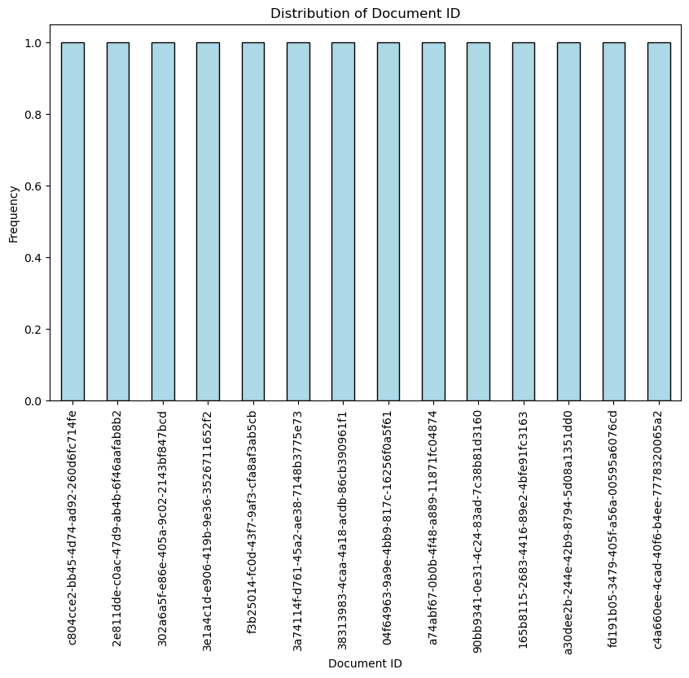

```python
import pandas as pd
import matplotlib.pyplot as plt

# Load the dataset into a Pandas DataFrame
# Assuming the dataset is already loaded and stored in a variable called 'df'
# If not, you can load it using pd.read_csv() or pd.read_excel(), depending on the file format

# Assuming 'DOC_ID_TXT' is the column of interest
document_id = df['DOC_ID_TXT']

# Display the first few rows of the column
print("First few rows of Document ID:")
print(document_id.head())

# Get summary statistics
summary_stats = document_id.describe()
print("\nSummary Statistics for Document ID:")
print(summary_stats)

# Get unique values and their counts
unique_values_counts = document_id.value_counts()
print("\nUnique Values and Counts for Document ID:")
print(unique_values_counts)

# Plot a bar chart to visualize the distribution of values
plt.figure(figsize=(10, 6))
unique_values_counts.plot(kind='bar', color='lightblue', edgecolor='black')
plt.title('Distribution of Document ID')
plt.xlabel('Document ID')
plt.ylabel('Frequency')
plt.grid(False)
plt.show()
```

# 12 -- DOC_TYPE_DESC Type of ID presented.

```
First few rows of Document Type:
0    Drivers License
1            license
2            License
3    Drivers License
4            License
Name: DOC_TYPE_DESC, dtype: object

Summary Statistics for Document Type:
count                  15
unique                  7
top       Drivers License
freq                    4
Name: DOC_TYPE_DESC, dtype: object

Unique Values and Counts for Document Type:
Drivers License        4
License                4
Identification Card    2
Passport               2
license                1
Border Card            1
DMV Paper              1
Name: DOC_TYPE_DESC, dtype: int64
```

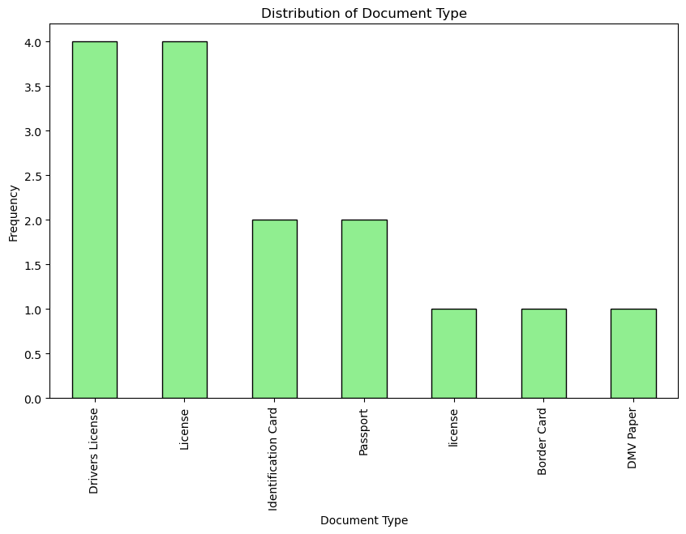

```python
import pandas as pd
import matplotlib.pyplot as plt

# Load the dataset into a Pandas DataFrame
# Assuming the dataset is already loaded and stored in a variable called 'df'
# If not, you can load it using pd.read_csv() or pd.read_excel(), depending on the file format

# Assuming 'DOC_TYPE_DESC' is the column of interest
document_type = df['DOC_TYPE_DESC']

# Display the first few rows of the column
print("First few rows of Document Type:")
print(document_type.head())

# Get summary statistics
summary_stats = document_type.describe()
print("\nSummary Statistics for Document Type:")
print(summary_stats)

# Get unique values and their counts
unique_values_counts = document_type.value_counts()
print("\nUnique Values and Counts for Document Type:")
print(unique_values_counts)

# Plot a bar chart to visualize the distribution of values
plt.figure(figsize=(10, 6))
unique_values_counts.plot(kind='bar', color='lightgreen', edgecolor='black')
plt.title('Distribution of Document Type')
plt.xlabel('Document Type')
plt.ylabel('Frequency')
plt.grid(False)
plt.show()
```

# 13 -- DVC_TYPE_DESC Type of Device the transaction originated from.

```
First few rows of Device Type:
0        IOS
1    Desktop
2        IOS
3        IOS
4        IOS
Name: DVC_TYPE_DESC, dtype: object

Summary Statistics for Device Type:
count      15
unique      2
top       IOS
freq       12
Name: DVC_TYPE_DESC, dtype: object

Unique Values and Counts for Device Type:
IOS        12
Desktop     3
Name: DVC_TYPE_DESC, dtype: int64
```

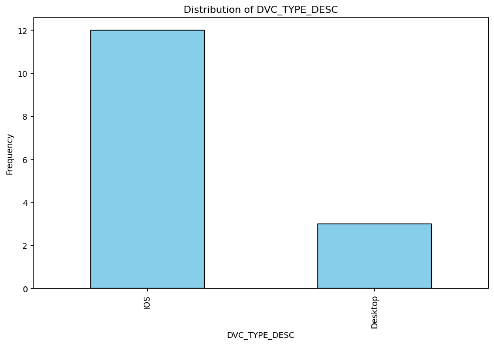

```python
import pandas as pd

# Load the dataset into a Pandas DataFrame
# Assuming the dataset is already loaded and stored in a variable called 'df'
# If not, you can load it using pd.read_csv() or pd.read_excel(), depending on the file format

# Assuming 'DVC_TYPE_DESC' is the column of interest
device_type = df['DVC_TYPE_DESC']

# Display the first few rows of the column
print("First few rows of Device Type:")
print(device_type.head())

# Get summary statistics
summary_stats = device_type.describe()
print("\nSummary Statistics for Device Type:")
print(summary_stats)

# Get unique values and their counts
unique_values_counts = device_type.value_counts()
print("\nUnique Values and Counts for Device Type:")
print(unique_values_counts)

# Plot a bar chart to visualize the distribution of values
plt.figure(figsize=(10, 6))
unique_values_counts.plot(kind='bar', color='skyblue', edgecolor='black')
plt.title('Distribution of DVC_TYPE_DESC')
plt.xlabel('DVC_TYPE_DESC')
plt.ylabel('Frequency')
plt.grid(False)
plt.show()
```

# 14 -- FLW_TYPE_CD A code value that describes the flow type

```
First few rows of Flow Type Code:
0    NewActivation
1    NewActivation
2    NewActivation
3    NewActivation
4      ExistingWLS
Name: FLW_TYPE_CD, dtype: object

Summary Statistics for Flow Type Code:
count                15
unique                2
top       NewActivation
freq                 13
Name: FLW_TYPE_CD, dtype: object

Unique Values and Counts for Flow Type Code:
NewActivation    13
ExistingWLS       2
Name: FLW_TYPE_CD, dtype: int64
```

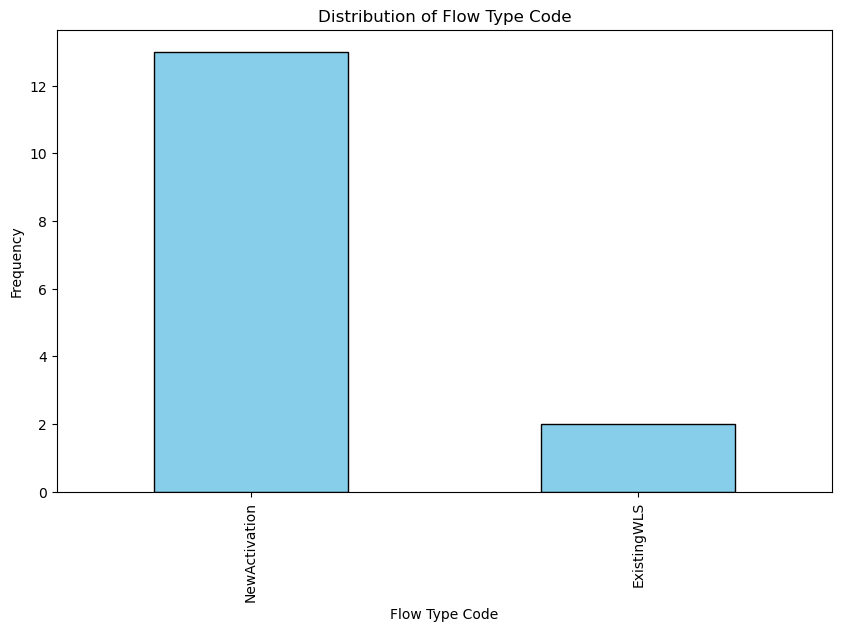

```python
import pandas as pd

# Load the dataset into a Pandas DataFrame
# Assuming the dataset is already loaded and stored in a variable called 'df'
# If not, you can load it using pd.read_csv() or pd.read_excel(), depending on the file format

# Assuming 'FLW_TYPE_CD' is the column of interest
flow_type_code = df['FLW_TYPE_CD']

# Display the first few rows of the column
print("First few rows of Flow Type Code:")
print(flow_type_code.head())

# Get summary statistics
summary_stats = flow_type_code.describe()
print("\nSummary Statistics for Flow Type Code:")
print(summary_stats)

# Get unique values and their counts
unique_values_counts = flow_type_code.value_counts()
print("\nUnique Values and Counts for Flow Type Code:")
print(unique_values_counts)

# Plot a bar chart to visualize the distribution of values
plt.figure(figsize=(10, 6))
unique_values_counts.plot(kind='bar', color='skyblue', edgecolor='black')
plt.title('Distribution of Flow Type Code')
plt.xlabel('Flow Type Code')
plt.ylabel('Frequency')
plt.grid(False)
plt.show()
```

# 15 -- IDTN_CLSFCTN_TXT Classification of the ID presented.

```
First few rows of ID Classification:
0                   NaN
1    UnknownnullUnknown
2                   NaN
3                   NaN
4                   NaN
Name: IDTN_CLSFCTN_TXT, dtype: object

Unique Values and Counts for ID Classification:
UnknownnullUnknown    1
Name: IDTN_CLSFCTN_TXT, dtype: int64
```

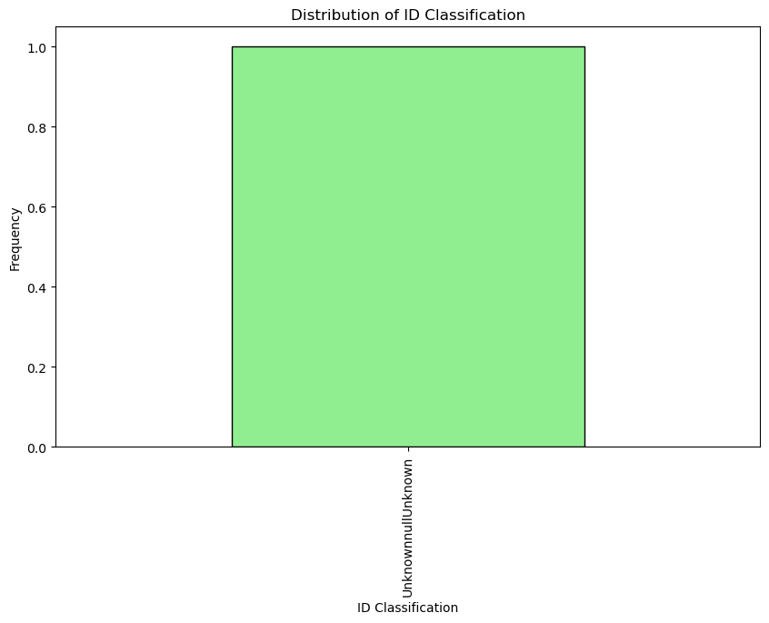

```python
import pandas as pd
import matplotlib.pyplot as plt

# Load the dataset into a Pandas DataFrame
# Assuming the dataset is already loaded and stored in a variable called 'df'
# If not, you can load it using pd.read_csv() or pd.read_excel(), depending on the file format

# Assuming 'IDTN_CLSFCTN_TXT' is the column of interest
id_classification = df['IDTN_CLSFCTN_TXT']

# Display the first few rows of the column
print("First few rows of ID Classification:")
print(id_classification.head())

# Get unique values and their counts
unique_values_counts = id_classification.value_counts()
print("\nUnique Values and Counts for ID Classification:")
print(unique_values_counts)

# Plot a bar chart to visualize the distribution of values
plt.figure(figsize=(10, 6))
unique_values_counts.plot(kind='bar', color='lightgreen', edgecolor='black')
plt.title('Distribution of ID Classification')
plt.xlabel('ID Classification')
plt.ylabel('Frequency')
plt.grid(False)
plt.show()
```

# 16 -- LOAD_BTH_ID Batch Processing ID

```
First few rows of Batch Processing ID:
0    2024040102
1    2024040102
2    2024040102
3    2024040102
4    2024040102
Name: LOAD_BTH_ID, dtype: int64

Unique Values and Counts for Batch Processing ID:
2024040102    15
Name: LOAD_BTH_ID, dtype: int64
```

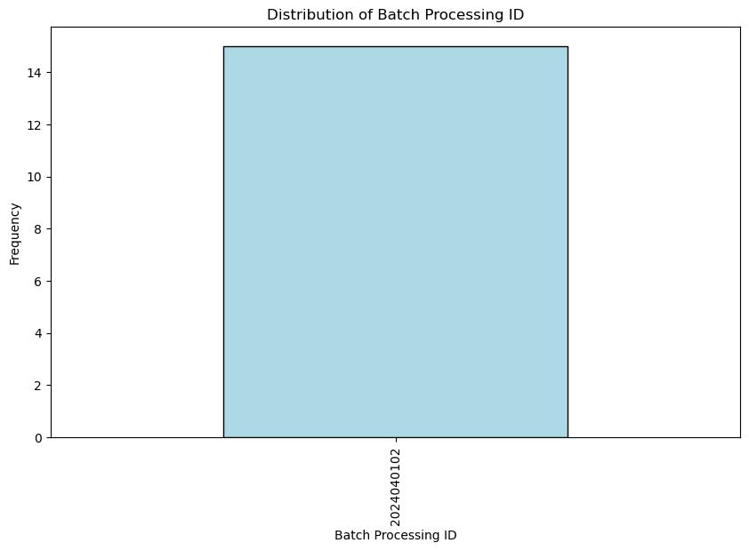

```python
import pandas as pd
import matplotlib.pyplot as plt

# Load the dataset into a Pandas DataFrame
# Assuming the dataset is already loaded and stored in a variable called 'df'
# If not, you can load it using pd.read_csv() or pd.read_excel(), depending on the file format

# Assuming 'LOAD_BTH_ID' is the column of interest
batch_processing_id = df['LOAD_BTH_ID']

# Display the first few rows of the column
print("First few rows of Batch Processing ID:")
print(batch_processing_id.head())

# Get unique values and their counts
unique_values_counts = batch_processing_id.value_counts()
print("\nUnique Values and Counts for Batch Processing ID:")
print(unique_values_counts)

# Plot a bar chart to visualize the distribution of values
plt.figure(figsize=(10, 6))
unique_values_counts.plot(kind='bar', color='lightblue', edgecolor='black')
plt.title('Distribution of Batch Processing ID')
plt.xlabel('Batch Processing ID')
plt.ylabel('Frequency')
plt.grid(False)
plt.show()
```

# 17 -- LOAD_DT_TM The date and time the row was loaded to the table.

```
First few rows of Load Date and Time:
0    2024-04-30T02:48:47.000+0000
1    2024-04-30T02:48:47.000+0000
2    2024-04-30T02:48:47.000+0000
3    2024-04-30T02:48:47.000+0000
4    2024-04-30T02:48:47.000+0000
Name: LOAD_DT_TM, dtype: object

Unique Values and Counts for Load Date and Time:
2024-04-30T02:48:47.000+0000    15
Name: LOAD_DT_TM, dtype: int64
```

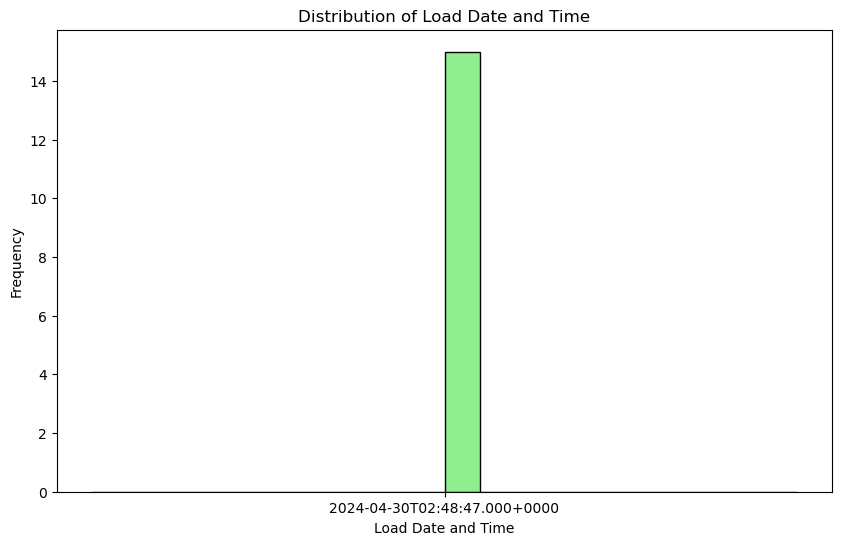

```python
import pandas as pd
import matplotlib.pyplot as plt

# Load the dataset into a Pandas DataFrame
# Assuming the dataset is already loaded and stored in a variable called 'df'
# If not, you can load it using pd.read_csv() or pd.read_excel(), depending on the file format

# Assuming 'LOAD_DT_TM' is the column of interest
load_date_time = df['LOAD_DT_TM']

# Display the first few rows of the column
print("First few rows of Load Date and Time:")
print(load_date_time.head())

# Get unique values and their counts
unique_values_counts = load_date_time.value_counts()
print("\nUnique Values and Counts for Load Date and Time:")
print(unique_values_counts)

# Plot a histogram to visualize the distribution of values
plt.figure(figsize=(10, 6))
load_date_time.hist(bins=20, color='lightgreen', edgecolor='black')
plt.title('Distribution of Load Date and Time')
plt.xlabel('Load Date and Time')
plt.ylabel('Frequency')
plt.grid(False)
plt.show()
```

# 18 -- NTWRK_NM Network name from where request originated.

```python
import pandas as pd
import matplotlib.pyplot as plt

# Load the dataset into a Pandas DataFrame
# Assuming the dataset is already loaded and stored in a variable called 'df'
# If not, you can load it using pd.read_csv() or pd.read_excel(), depending on the file format

# Assuming 'NTWRK_NM' is the column of interest
network_name = df['NTWRK_NM']

# Display the first few rows of the column
print("First few rows of Network Name:")
print(network_name.head())

# Get unique values and their counts
unique_values_counts = network_name.value_counts()

# Plot a bar chart only if there are values in the column
if not unique_values_counts.empty:
    print("\nUnique Values and Counts for Network Name:")
    print(unique_values_counts)

    # Plot a bar chart to visualize the distribution of values
    plt.figure(figsize=(10, 6))
    unique_values_counts.plot(kind='bar', color='lightblue', edgecolor='black')
    plt.title('Distribution of Network Name')
    plt.xlabel('Network Name')
    plt.ylabel('Frequency')
    plt.grid(False)
    plt.show()
else:
    print("\nNo data available for Network Name.")
```

```
First few rows of Network Name:
0   NaN
1   NaN
2   NaN
3   NaN
4   NaN
Name: NTWRK_NM, dtype: float64

No data available for Network Name.
```

# 19 -- PAY_LOAD_SIZE_TXT Front and Back images sizes in KB.

```
First few rows of Payload Size (KB):
0    0,0
1     9,
2    0,0
3    0,0
4    0,0
Name: PAY_LOAD_SIZE_TXT, dtype: object
```

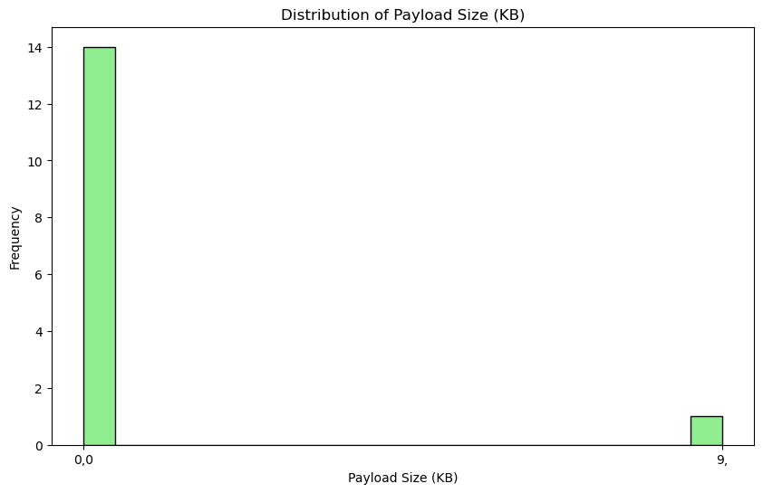

```python
import pandas as pd
import matplotlib.pyplot as plt

# Load the dataset into a Pandas DataFrame
# Assuming the dataset is already loaded and stored in a variable called 'df'
# If not, you can load it using pd.read_csv() or pd.read_excel(), depending on the file format

# Assuming 'PAY_LOAD_SIZE_TXT' is the column of interest
payload_size = df['PAY_LOAD_SIZE_TXT']

# Display the first few rows of the column
print("First few rows of Payload Size (KB):")
print(payload_size.head())

# Get unique values and their counts
unique_values_counts = payload_size.value_counts()

# Plot a histogram to visualize the distribution of values
plt.figure(figsize=(10, 6))
payload_size.hist(bins=20, color='lightgreen', edgecolor='black')
plt.title('Distribution of Payload Size (KB)')
plt.xlabel('Payload Size (KB)')
plt.ylabel('Frequency')
plt.grid(False)
plt.show()
```

# 20 -- POSS_PRTY_ID unique identifier for this POS Agent who actually sold the item and will get credit in compensation for the sale. May be different than the User who is currently logged on to the cash register.

```
First few rows of POS Agent ID:
0   -544015402
1   -551012822
2   -546785552
3   -557699822
4   -555145132
Name: POSS_PRTY_ID, dtype: int64
```

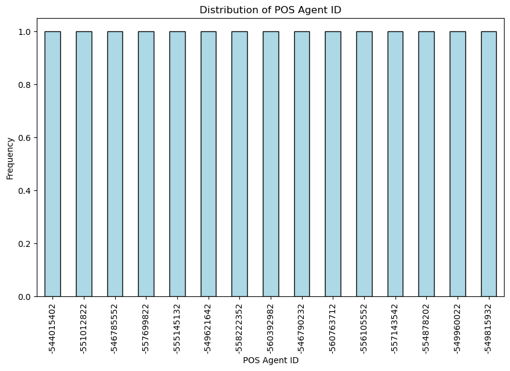

```python
import pandas as pd
import matplotlib.pyplot as plt

# Load the dataset into a Pandas DataFrame
# Assuming the dataset is already loaded and stored in a variable called 'df'
# If not, you can load it using pd.read_csv() or pd.read_excel(), depending on the file format

# Assuming 'POSS_PRTY_ID' is the column of interest
pos_agent_id = df['POSS_PRTY_ID']

# Display the first few rows of the column
print("First few rows of POS Agent ID:")
print(pos_agent_id.head())

# Get unique values and their counts
unique_values_counts = pos_agent_id.value_counts()

# Plot a bar chart to visualize the distribution of values
plt.figure(figsize=(10, 6))
unique_values_counts.plot(kind='bar', color='lightblue', edgecolor='black')
plt.title('Distribution of POS Agent ID')
plt.xlabel('POS Agent ID')
plt.ylabel('Frequency')
plt.grid(False)
plt.show()
```

# 21 -- POSS_TRANS_ID A surrogate key that uniquely identifies a Point of Sale Transaction Code.

```
First few rows of POS Transaction ID:
0    392476101
1    392512933
2    392487863
3    392561139
4    392542637
Name: POSS_TRANS_ID, dtype: int64
```

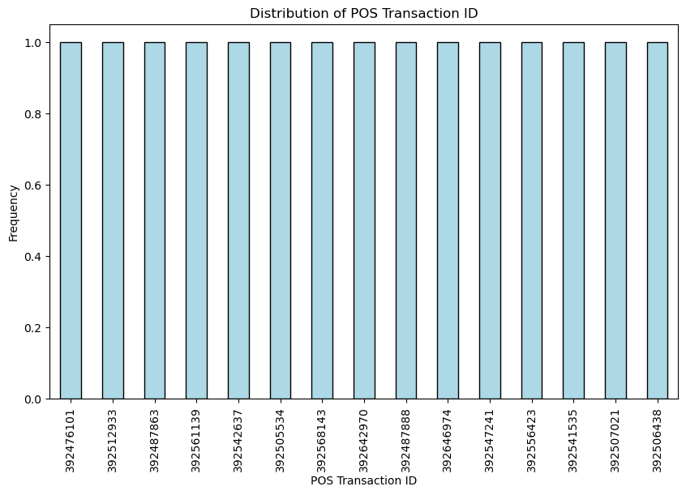

```python
import pandas as pd
import matplotlib.pyplot as plt

# Load the dataset into a Pandas DataFrame
# Assuming the dataset is already loaded and stored in a variable called 'df'
# If not, you can load it using pd.read_csv() or pd.read_excel(), depending on the file format

# Assuming 'POSS_TRANS_ID' is the column of interest
pos_transaction_id = df['POSS_TRANS_ID']

# Display the first few rows of the column
print("First few rows of POS Transaction ID:")
print(pos_transaction_id.head())

# Get unique values and their counts
unique_values_counts = pos_transaction_id.value_counts()

# Plot a bar chart to visualize the distribution of values
plt.figure(figsize=(10, 6))
unique_values_counts.plot(kind='bar', color='lightblue', edgecolor='black')
plt.title('Distribution of POS Transaction ID')
plt.xlabel('POS Transaction ID')
plt.ylabel('Frequency')
plt.grid(False)
plt.show()
```

# 22 - RGSTR_IP_ADDR Register IP Address.

```python
import pandas as pd
import matplotlib.pyplot as plt

# Load the dataset into a Pandas DataFrame
# Assuming the dataset is already loaded and stored in a variable called 'df'
# If not, you can load it using pd.read_csv() or pd.read_excel(), depending on the file format

# Assuming 'RGSTR_IP_ADDR' is the column of interest
register_ip_address = df['RGSTR_IP_ADDR']

# Display the first few rows of the column
print("First few rows of Register IP Address:")
print(register_ip_address.head())

# Get unique values and their counts
unique_values_counts = register_ip_address.value_counts()

# Plot a bar chart only if there are values in the column
if not unique_values_counts.empty:
    # Plot a bar chart to visualize the distribution of values
    plt.figure(figsize=(10, 6))
    unique_values_counts.plot(kind='bar', color='lightblue', edgecolor='black')
    plt.title('Distribution of Register IP Address')
    plt.xlabel('Register IP Address')
    plt.ylabel('Frequency')
    plt.grid(False)
    plt.show()
else:
    print("\nNo data available for Register IP Address.")
```

```
First few rows of Register IP Address:
0   NaN
1   NaN
2   NaN
3   NaN
4   NaN
Name: RGSTR_IP_ADDR, dtype: float64

No data available for Register IP Address.
```

# 23 -- RSLT_DESC Description of the API response

```
First few rows of API Response Description:
0    Upload complete. You may now close this window.99
1    null ActionCode=35EnvironmentManually entered ...
2    SendLink - MitigationAuthenticIDRemote API Cal...
3    Upload complete. You may now close this window.99
4    SendLink - MitigationAuthenticIDRemote API Cal...
Name: RSLT_DESC, dtype: object
```

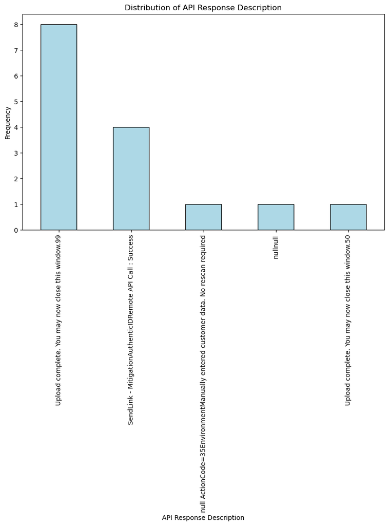

```python
import pandas as pd
import matplotlib.pyplot as plt

# Load the dataset into a Pandas DataFrame
# Assuming the dataset is already loaded and stored in a variable called 'df'
# If not, you can load it using pd.read_csv() or pd.read_excel(), depending on the file format

# Assuming 'RSLT_DESC' is the column of interest
api_response_description = df['RSLT_DESC']

# Display the first few rows of the column
print("First few rows of API Response Description:")
print(api_response_description.head())

# Get unique values and their counts
unique_values_counts = api_response_description.value_counts()

# Plot a bar chart to visualize the distribution of values
plt.figure(figsize=(10, 6))
unique_values_counts.plot(kind='bar', color='lightblue', edgecolor='black')
plt.title('Distribution of API Response Description')
plt.xlabel('API Response Description')
plt.ylabel('Frequency')
plt.grid(False)
plt.show()
```